# Taller Introducción al lenguaje R con un enfoque espacial

Instalación de programas

Luis Balcázar

Toluca, México, diciembre 2020

En este documento usted encontrará los *links* para descargar los programas R, Rtools, RStudio, SAGA, y algunos paquetes de R. La instalación le tomará un tiempo estimado entre 20 y 30 minutos.

Los datos para el taller se encuentran en el siguiente [repositorio](https://github.com/lebalcazar/R_IITCA.git) (estará disponible minutos antes del taller). Es recomendable que usted tenga otro dispositivo aparte de su computador para ver la presentación y realizar los ejercicios en la máquina que tiene R y RStudio.

Además, descargue los siguientes datos de [Senegal](https://www.dropbox.com/s/tkkqyz2kaqoh4cj/DEM_Senegal.7z?dl=0) y [México](http://www.conabio.gob.mx/informacion/metadata/gis/dipoest00gw.xml?_xsl=/db/metadata/xsl/fgdc_html.xsl&_indent=no), para este último elegir SHP1 “en coordenadas geográficas”.

## Instalación de R y RStudio

Ingrese a la página de **CRAN** (*The Comprehensive $R$ Archive Network*) en [este link](https://cran.r-project.org/) y descargue **R** para el sistema operativo de su PC (Linux/Window) o Mac. En una PC Windows seleccione Download R for Windows/base y descargue la versión reciente 4.x.x. Además, para máquinas con Windows es necesario descargar **Rtools** del [siguiente link](https://cran.r-project.org/bin/windows/Rtools/).

Para descargar **RStudio** ingrese en [este link](https://rstudio.com/products/rstudio/) y seleccione la pestaña *DOWNLOAD* (en la parte superior derecha) y luego *RStudio Desktop* en la versión gratuita.

Instale **R**, luego **Rtools** y finalmente **Rstudio**, siga las indicaciones de instalación típica.

## Primera sesión de R desde RStudio

Ejecute RStudio y se cargará automáticamente R. Al abrir RStudio por primera vez se mostrará como en la Figura . Por defecto el entorno de RStudio tiene 4 paneles, los cuales se pueden modificar en la pestaña *View/Panes*. Además, en la pestaña *Tools* puede cambiar la configuración: color de fondo, tamaño y tipo de letra, etc.

[figure not shown]

Interfaz de RStudio.

En la Figura , el panel (1) es el **Editor** de código (presione las teclas `Ctrl+Shift+N` para que aparezca), en el panel (2) se encuentran la *Console* de R y el **Terminal**, en el panel (3) se observan las pestañas **Environment**, **History** y otros, y en el panel (4) se encuentran las opciones *Files*, **Packages**, **Plots** y **Help**.

## Instalación de paquetes

El programa `base` de R tiene un amplio conjunto de librerías para hacer análisis de datos y estadístico, así como gráficos de alta calidad. Sin embargo, existen otros paquetes que son útiles para mejorar los resultados y reducir las líneas de código.

En la consola de RStudio escriba `install.packages()`, como se muestra en las líneas siguientes, para instalar las librerías tidyverse, tmap, lubridate y raster.

```r
install.packages('tidyverse', 'tmap', 'lubridate', 'raster')
```

Para cargar las librerías en la sesión de R utilice la función `library()`. Observe que para cargar los paquetes, no se utiliza las comillas en los nombres:

```r
# librerías que se cargarán en la sesión de R
library(tidyverse)  # familia de paquetes para el análisis de datos
library(tmap)       # creación de mapas temáticos
library(lubridate)  # procesamiento de fecha y tiempo
library(raster)     # análisis de datos raster
```

Una vez cargada(s) la(s) librería(s) en la sesión de R, abrir la ayuda de los paquetes para familiarse con ellos, escriba en la consola o editor: `?raster`, `?tmap`, `help("tmap")`, etc., o desde el panel `Help` puede navegar en la ayuda.

Instale estos otros paquetes: `"sf", "ggmap", "mapproj", "osmar", "tidyverse", "RColorBrewer","dplyr", "RgoogleMaps", "OpenStreetMap", "devtools", "DT", "raster", "rgdal", "rworldxtra", 'grDevices', 'ggsn', 'tmap', 'utils', 'viridis', "datos", 'RColorBrewer', 'RSAGA', 'cptcity'`. Utilizar `install.packages()` como se mostró anteriormente.

Si alguna librería no se instala, ejecute las siguientes líneas, y vuelva a instalar:

```r
options(download.file.method = 'libcurl') # para conectar con la URL del paquete
install.packages('nombre_del_paquete', dependences = TRUE)
```

Otra opción para instalar paquetes es descargando los archivos binarios desde la página de CRAN: https://cran.r-project.org/ ver la Figura . Se descargan los archivos en un .zip. Luego en la pestaña Tools de RStudio ir a la pestaña Tools/Install Packages/Package Archive File y buscar la carpeta que contiene el archivo .zip.

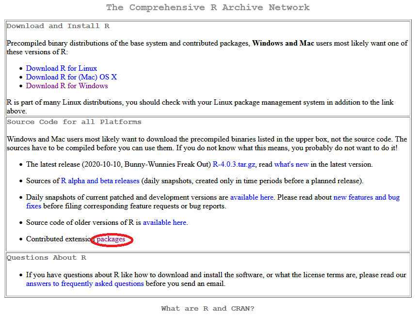

Lista de paquetes de R.

En otras ocasiones (**NO SERÁ NECESARIO EN ESTE TALLER**) los programas no están en CRAN y se instalan desde un servicio git (github, gitlab o bitbucket) o Subversion, se utiliza el paquete *remotes* o *devtools* de la siguiente manera:

```r
install.packages("remotes")
# sin cargar las librerías remotes o devtools
remotes::install_github('autor/package_name')

# cargando la librería remotes o devtools
library(remotes)
install_gitlab('autor/package_name')

#Una vez instalado, se puede cargar la librería normalmente
library(package_name)
```

## Instalar SAGA GIS

Descargar e instalar SAGA desde el siguiente [link](https://sourceforge.net/projects/saga-gis/files/). Elija la versión 6.3 que ha sido testeada con la versión de RSAGA.

[figure not shown]

Sitio web de SAGA.